# Coursework Report

*N* removed NAs: 2

*N* removed typo: 1

*N* removed <18: 34

[output not shown]

**Main analysis results**

[interactive chart not shown]

[figure not shown]

[interactive chart not shown]

# Coursework Report

Analysing Data, Spring 2020

# Methods

## Participants

Table 1. Descriptive Statistics by Age

| Group | Mean Age | SD Age | Min | Max |
| --- | --- | --- | --- | --- |
| control | 20.93 | 2.55 | 18 | 27 |
| experimental | 21.45 | 2.30 | 18 | 28 |

## Design

This study attempted to replicate Elliot et al’s (2010) study which investigated whether the colour red affects the perceived attractiveness of men by women. The independent variable of this study was colour, this was tested by showing participants a picture of a moderately attractive man in either a red frame(experimental condition) or in a white frame (control). the dependent variable was the ratings of attractiveness found using a rating scale between 1 and 9, where 1 is “not at all attractive” and 9 is “extremely attractive”. This scale was used to answer three questions: - “How attractive do you think this person is?” - “How pleasant is this person to look at?” - “If i were to meet the person in this picture face to face, i would think he is attractive”. The operationalised hypothesis was “will seeing a picture of a man in a red or white frame affect the mean ratings of attractiveness by women on a rating scale of 1 to 9, where 1 is”not at all attractive" and 9 is “extremely attractive”. this hypothesis was tested using a t-test.

# Results

This study investigated whether the colour red when paired with a picture of a man could affect the attractiveness ratings of women. this was tested using a two sided t-test. This t-test showed that the mean ratings across all three questions was higher in the experimental group than the control group (*M*<sub>diff</sub> = 1.490303, 95% CI[-1.22, -1.76]). Because the p-value is less than the 95% confidence, we can reject the null hypothesis (*t* (112) = -10.99, *p* = 0).

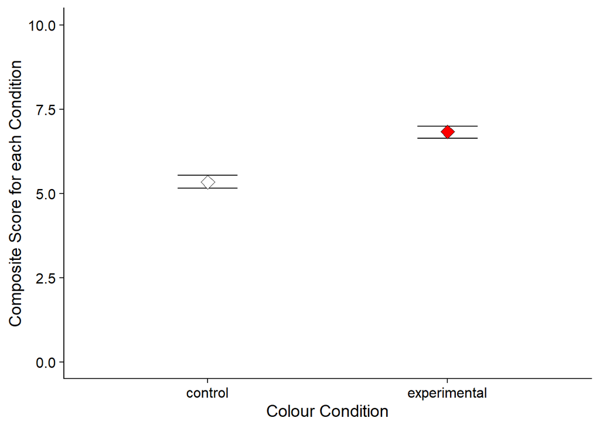

```
##
##  Two Sample t-test
##
## data:  opinion_comp by group
## t = -10.986, df = 112, p-value < 2.2e-16
## alternative hypothesis: true difference in means is not equal to 0
## 95 percent confidence interval:
##  -1.760286 -1.222354
## sample estimates:
##      mean in group control mean in group experimental
##                   5.338983                   6.830303
```

# Discussion

The results of this experiment provide support for the theory of the red effect on attractiveness. The results of this study mirror the results of Elliot et al’s original 2010 study, both these studys clearly found that the red frame produced higher attractiveness ratings than the white frame. Therefore, a similar pattern of results were found in this study, giving support to Elliot et al’s study and further evidencing the red effect. A strength of this study is the information collated, the questions asked are simple to understand and collect opinion data that is on a 9 point scale allowing for the participants to accurately portray their feelings in an easy to calculate quantitative way. However a limitation may be that this study does not show causation, only correlation. the colour red may not be the only factor affecting whether a woman may perceive a man to be more or less attractive. This study could be improved by testing more colours to see if the colour red still has the highest affect on percieved attractiveness. Little and Hill (2007) examined the associations between red and blue and found that red was percieved as more dominant, it may be useful to investigate the reasons why the participants gave those scores by having an open ended question to see if any associations of certain attractive qualities (like dominance) is found in relation to the photos of men on a red frame. This research has a lot of value, for example, it is valuable to understand how a persons opinion of attractivenss may change due to colour, but this research can also be used in multiple fields, for example in advertising, a person may be more attracted to or stimulated by a product depending on the colours it is presented alongside (Lichtle, 2015).

# References

Elliot, A. J., Niesta Kayser, D., Greitemeyer, T., Lichtenfeld, S., Gramzow, R. H., Maier, M. A., & Liu, H. (2010). Red, rank, and romance in women viewing men. *Journal of Experimental Psychology: General, 139*(3), 399.

Little, A. C., & Hill, R. A. (2007). Attribution to red suggests special role in dominance signalling. *Journal of Evolutionary Psychology, 5*(1), 161–168.**

Lictle, M. (2015). The effect of an advertisement’s colour on emotions evoked by attitude towards the ad: The moderating role of the optimal stimulation level. *International Journal of Advertising, 1*